**Reading data into R**

```r
library(tidyverse)
append_data <- read_csv("app_data.csv")
```

```
## ──────────────────────────────────────────────────────── Delimiter: "," chr
## (40): Sex, Management, Severity, Diagnosis_Presumptive, Diagnosis, Appen... dbl
## (18): Age, BMI, Height, Weight, Length_of_Stay, Alvarado_Score, Paedriat... lgl
## (11): ...59, ...60, ...61, ...62, ...63, ...64, ...65, ...66, ...67, ......
```

```r
head(append_data)
```

```
## # A tibble: 6 × 69
##     Age   BMI Sex    Height Weight Length_of_Stay Management   Severity
##   <dbl> <dbl> <chr>   <dbl>  <dbl>          <dbl> <chr>        <chr>
## 1  12.7  16.9 female    148   37                3 conservative uncomplicated
## 2  14.1  31.9 male      147   69.5              2 conservative uncomplicated
## 3  14.1  23.3 female    163   62                4 conservative uncomplicated
## 4  16.4  20.6 female    165   56                3 conservative uncomplicated
## 5  11.1  16.9 female    163   45                3 conservative uncomplicated
## 6  11.0  30.7 male      121   45                3 conservative uncomplicated
## # ℹ 61 more variables: Diagnosis_Presumptive <chr>, Diagnosis <chr>,
## #   Alvarado_Score <dbl>, Paedriatic_Appendicitis_Score <dbl>,
## #   Appendix_on_US <chr>, Appendix_Diameter <dbl>, Migratory_Pain <chr>,
## #   Lower_Right_Abd_Pain <chr>, Contralateral_Rebound_Tenderness <chr>,
## #   Coughing_Pain <chr>, Nausea <chr>, Loss_of_Appetite <chr>,
## #   Body_Temperature <dbl>, WBC_Count <dbl>, Neutrophil_Percentage <dbl>,
## #   Segmented_Neutrophils <dbl>, Neutrophilia <chr>, RBC_Count <dbl>, …
```

**Data length - Original**

```r
nrow(append_data)
```

```
## [1] 782
```

**Number of Variables - Original**

```r
ncol(append_data)
```

```
## [1] 69
```

**Removing NA values**

There was many NA values in the dataset, some columns with over 50% missing values.

```r
threshold <- 0.5
reduced <- append_data %>%
  select_if(~ mean(is.na(.)) <= threshold)
```

```r
data_mutate <- reduced %>%
  mutate(across(everything(), ~ ifelse(is.na(.), mean(., na.rm = TRUE), .)))
```

**Clean Data**

```r
row_threshold <- 1
clean_data <- data_mutate %>%
  filter(rowSums(is.na(.)) <= row_threshold)

clean_data
```

```
## # A tibble: 544 × 40
##      Age   BMI Sex    Height Weight Length_of_Stay Management   Severity
##    <dbl> <dbl> <chr>   <dbl>  <dbl>          <dbl> <chr>        <chr>
##  1 12.7   16.9 female    148   37                3 conservative uncomplicated
##  2 14.1   31.9 male      147   69.5              2 conservative uncomplicated
##  3 14.1   23.3 female    163   62                4 conservative uncomplicated
##  4 16.4   20.6 female    165   56                3 conservative uncomplicated
##  5 11.1   16.9 female    163   45                3 conservative uncomplicated
##  6 11.0   30.7 male      121   45                3 conservative uncomplicated
##  7  8.98  19.4 female    140   38.5              3 conservative uncomplicated
##  8  7.9   15.7 male      131   26.7              3 conservative uncomplicated
##  9 14.3   14.9 male      174   45.5              3 conservative uncomplicated
## 10 11.9   15.7 male      147   34                2 conservative uncomplicated
## # ℹ 534 more rows
## # ℹ 32 more variables: Diagnosis_Presumptive <chr>, Diagnosis <chr>,
## #   Alvarado_Score <dbl>, Paedriatic_Appendicitis_Score <dbl>,
## #   Appendix_on_US <chr>, Appendix_Diameter <dbl>, Migratory_Pain <chr>,
## #   Lower_Right_Abd_Pain <chr>, Contralateral_Rebound_Tenderness <chr>,
## #   Coughing_Pain <chr>, Nausea <chr>, Loss_of_Appetite <chr>,
## #   Body_Temperature <dbl>, WBC_Count <dbl>, Neutrophil_Percentage <dbl>, …
```

- Remove NA values.

```r
library(car)
clean_data <- clean_data %>%
  mutate(across(where(is.character), as.factor))

clean_data
```

```
## # A tibble: 544 × 40
##      Age   BMI Sex    Height Weight Length_of_Stay Management   Severity
##    <dbl> <dbl> <fct>   <dbl>  <dbl>          <dbl> <fct>        <fct>
##  1 12.7   16.9 female    148   37                3 conservative uncomplicated
##  2 14.1   31.9 male      147   69.5              2 conservative uncomplicated
##  3 14.1   23.3 female    163   62                4 conservative uncomplicated
##  4 16.4   20.6 female    165   56                3 conservative uncomplicated
##  5 11.1   16.9 female    163   45                3 conservative uncomplicated
##  6 11.0   30.7 male      121   45                3 conservative uncomplicated
##  7  8.98  19.4 female    140   38.5              3 conservative uncomplicated
##  8  7.9   15.7 male      131   26.7              3 conservative uncomplicated
##  9 14.3   14.9 male      174   45.5              3 conservative uncomplicated
## 10 11.9   15.7 male      147   34                2 conservative uncomplicated
## # ℹ 534 more rows
## # ℹ 32 more variables: Diagnosis_Presumptive <fct>, Diagnosis <fct>,
## #   Alvarado_Score <dbl>, Paedriatic_Appendicitis_Score <dbl>,
## #   Appendix_on_US <fct>, Appendix_Diameter <dbl>, Migratory_Pain <fct>,
## #   Lower_Right_Abd_Pain <fct>, Contralateral_Rebound_Tenderness <fct>,
## #   Coughing_Pain <fct>, Nausea <fct>, Loss_of_Appetite <fct>,
## #   Body_Temperature <dbl>, WBC_Count <dbl>, Neutrophil_Percentage <dbl>, …
```

- Convert the variables that are of the character type to factors.

```r
unique(clean_data$Ketones_in_Urine)
```

```
## [1] ++  no  +++ +
## Levels: + ++ +++ no
```

```r
unique(clean_data$RBC_in_Urine)
```

```
## [1] +    no   ++   +++  <NA>
## Levels: + ++ +++ no
```

```r
unique(clean_data$WBC_in_Urine)
```

```
## [1] no  +   +++ ++
## Levels: + ++ +++ no
```

```r
clean_data <- clean_data[, !names(clean_data) %in% c("Ketones_in_Urine", "RBC_in_Urine", "WBC_in_Urine", "Free_Fluids")]
```

Remove any remaining variables with na

```r
clean_data <- na.omit(clean_data)
clean_data
```

```
## # A tibble: 448 × 36
##      Age   BMI Sex    Height Weight Length_of_Stay Management   Severity
##    <dbl> <dbl> <fct>   <dbl>  <dbl>          <dbl> <fct>        <fct>
##  1 12.7   16.9 female    148   37                3 conservative uncomplicated
##  2 14.1   31.9 male      147   69.5              2 conservative uncomplicated
##  3 14.1   23.3 female    163   62                4 conservative uncomplicated
##  4 16.4   20.6 female    165   56                3 conservative uncomplicated
##  5 11.1   16.9 female    163   45                3 conservative uncomplicated
##  6 11.0   30.7 male      121   45                3 conservative uncomplicated
##  7  8.98  19.4 female    140   38.5              3 conservative uncomplicated
##  8  7.9   15.7 male      131   26.7              3 conservative uncomplicated
##  9 14.3   14.9 male      174   45.5              3 conservative uncomplicated
## 10 11.9   15.7 male      147   34                2 conservative uncomplicated
## # ℹ 438 more rows
## # ℹ 28 more variables: Diagnosis_Presumptive <fct>, Diagnosis <fct>,
## #   Alvarado_Score <dbl>, Paedriatic_Appendicitis_Score <dbl>,
## #   Appendix_on_US <fct>, Appendix_Diameter <dbl>, Migratory_Pain <fct>,
## #   Lower_Right_Abd_Pain <fct>, Contralateral_Rebound_Tenderness <fct>,
## #   Coughing_Pain <fct>, Nausea <fct>, Loss_of_Appetite <fct>,
## #   Body_Temperature <dbl>, WBC_Count <dbl>, Neutrophil_Percentage <dbl>, …
```

```r
library(car)

# Fit a full linear regression model
full_model <- glm(Diagnosis ~ ., family = "binomial", data = clean_data)
summary(full_model)
```

```
##
## Call:
## glm(formula = Diagnosis ~ ., family = "binomial", data = clean_data)
##
## Coefficients:
##                                                                  Estimate
## (Intercept)                                                     6.384e+01
## Age                                                            -1.784e-01
## BMI                                                            -1.081e-01
## Sexmale                                                         4.954e-02
## Height                                                         -8.452e-02
## Weight                                                          1.466e-01
## Length_of_Stay                                                  1.011e+00
## Managementprimary surgical                                     -4.950e+01
## Managementsecondary surgical                                   -4.112e+01
## Severityuncomplicated                                          -2.281e+00
## Diagnosis_Presumptiveappendicitis                              -2.291e+01
## Diagnosis_PresumptiveAppendizitis, Lymphadenitis mesenterialis -2.234e+01
## Diagnosis_PresumptiveAppendizitis/ Lymphadenitis mesenterialis -2.571e+01
## Diagnosis_Presumptivechronische Appendizitis                   -1.941e+00
## Diagnosis_Presumptivediabetische Ketoazidose, Myokarditis      -3.218e+01
## Diagnosis_Presumptiveno appendicitis                           -2.316e+00
## Alvarado_Score                                                 -9.425e-01
## Paedriatic_Appendicitis_Score                                   3.763e-01
## Appendix_on_USyes                                              -2.899e+01
## Appendix_Diameter                                              -2.715e+00
## Migratory_Painyes                                              -8.741e-01
## Lower_Right_Abd_Painyes                                         9.914e-01
## Contralateral_Rebound_Tendernessyes                             3.546e-01
## Coughing_Painyes                                               -2.236e+00
## Nauseayes                                                      -2.183e+00
## Loss_of_Appetiteyes                                             5.783e-01
## Body_Temperature                                                8.964e-01
## WBC_Count                                                      -2.737e-01
## Neutrophil_Percentage                                           6.978e-02
## Neutrophiliayes                                                -2.016e-01
## RBC_Count                                                      -6.889e-01
## Hemoglobin                                                      3.636e-01
## RDW                                                            -1.642e-01
## Thrombocyte_Count                                               6.444e-03
```

[output cut: 140 more lines]

```
## Peritonitisno
## Psoas_Signyes
## Ipsilateral_Rebound_Tendernessyes
## US_Performedyes
## US_Number
## ---
## Signif. codes:  0 '***' 0.001 '**' 0.01 '*' 0.05 '.' 0.1 ' ' 1
##
## (Dispersion parameter for binomial family taken to be 1)
##
##     Null deviance: 617.117  on 447  degrees of freedom
## Residual deviance:  95.791  on 404  degrees of freedom
## AIC: 183.79
##
## Number of Fisher Scoring iterations: 21
```

```r
# Calculate VIF for each predictor in the model
vif_values <- vif(full_model)
avg_gvif <- mean(vif_values)
avg_gvif
```

```
## [1] 3.551276
```

Perform Subset Selection

AIC

```r
library(car)

full_model <- suppressWarnings(glm(Diagnosis ~ ., family = "binomial", data = clean_data))
summary(full_model)
```

```
##
## Call:
## glm(formula = Diagnosis ~ ., family = "binomial", data = clean_data)
##
## Coefficients:
##                                                                  Estimate
## (Intercept)                                                     6.384e+01
## Age                                                            -1.784e-01
## BMI                                                            -1.081e-01
## Sexmale                                                         4.954e-02
## Height                                                         -8.452e-02
## Weight                                                          1.466e-01
## Length_of_Stay                                                  1.011e+00
## Managementprimary surgical                                     -4.950e+01
## Managementsecondary surgical                                   -4.112e+01
## Severityuncomplicated                                          -2.281e+00
## Diagnosis_Presumptiveappendicitis                              -2.291e+01
## Diagnosis_PresumptiveAppendizitis, Lymphadenitis mesenterialis -2.234e+01
## Diagnosis_PresumptiveAppendizitis/ Lymphadenitis mesenterialis -2.571e+01
## Diagnosis_Presumptivechronische Appendizitis                   -1.941e+00
## Diagnosis_Presumptivediabetische Ketoazidose, Myokarditis      -3.218e+01
## Diagnosis_Presumptiveno appendicitis                           -2.316e+00
## Alvarado_Score                                                 -9.425e-01
## Paedriatic_Appendicitis_Score                                   3.763e-01
## Appendix_on_USyes                                              -2.899e+01
## Appendix_Diameter                                              -2.715e+00
## Migratory_Painyes                                              -8.741e-01
## Lower_Right_Abd_Painyes                                         9.914e-01
## Contralateral_Rebound_Tendernessyes                             3.546e-01
## Coughing_Painyes                                               -2.236e+00
## Nauseayes                                                      -2.183e+00
## Loss_of_Appetiteyes                                             5.783e-01
## Body_Temperature                                                8.964e-01
## WBC_Count                                                      -2.737e-01
## Neutrophil_Percentage                                           6.978e-02
## Neutrophiliayes                                                -2.016e-01
## RBC_Count                                                      -6.889e-01
## Hemoglobin                                                      3.636e-01
## RDW                                                            -1.642e-01
## Thrombocyte_Count                                               6.444e-03
```

[output cut: 140 more lines]

```
## Peritonitisno
## Psoas_Signyes
## Ipsilateral_Rebound_Tendernessyes
## US_Performedyes
## US_Number
## ---
## Signif. codes:  0 '***' 0.001 '**' 0.01 '*' 0.05 '.' 0.1 ' ' 1
##
## (Dispersion parameter for binomial family taken to be 1)
##
##     Null deviance: 617.117  on 447  degrees of freedom
## Residual deviance:  95.791  on 404  degrees of freedom
## AIC: 183.79
##
## Number of Fisher Scoring iterations: 21
```

```r
vif_values <- suppressWarnings(vif(full_model))
print(vif_values)
```

```
##                                       GVIF Df GVIF^(1/(2*Df))
## Age                               5.049054  1        2.247010
## BMI                              26.111974  1        5.109988
## Sex                               1.990721  1        1.410929
## Height                           13.950965  1        3.735099
## Weight                           58.893661  1        7.674221
## Length_of_Stay                    1.855783  1        1.362271
## Management                        2.308936  2        1.232687
## Severity                          1.688213  1        1.299313
## Diagnosis_Presumptive             1.029951  6        1.002462
## Alvarado_Score                   23.463264  1        4.843889
## Paedriatic_Appendicitis_Score    40.577579  1        6.370053
## Appendix_on_US                    1.579471  1        1.256770
## Appendix_Diameter                 4.759601  1        2.181651
## Migratory_Pain                    3.318526  1        1.821682
## Lower_Right_Abd_Pain              2.508774  1        1.583911
## Contralateral_Rebound_Tenderness  2.691994  1        1.640730
## Coughing_Pain                    13.872368  1        3.724563
## Nausea                            4.123480  1        2.030635
## Loss_of_Appetite                  3.490362  1        1.868251
## Body_Temperature                  3.872402  1        1.967842
## WBC_Count                         3.853921  1        1.963141
## Neutrophil_Percentage             5.028196  1        2.242364
## Neutrophilia                      4.942543  1        2.223183
## RBC_Count                         1.934588  1        1.390895
## Hemoglobin                        2.875721  1        1.695795
## RDW                               2.107480  1        1.451716
## Thrombocyte_Count                 1.635412  1        1.278832
## CRP                               2.226738  1        1.492226
## Dysuria                           1.504640  1        1.226638
## Stool                             2.061592  2        1.198259
## Peritonitis                       1.340380  2        1.075987
## Psoas_Sign                        1.837531  1        1.355556
## Ipsilateral_Rebound_Tenderness    1.587713  1        1.260045
## US_Performed                      1.009546  1        1.004762
## US_Number                         2.121116  1        1.456405
```

```r
AIC_model <- suppressWarnings(step(full_model, direction = "both"))
```

```
## Start:  AIC=183.79
## Diagnosis ~ Age + BMI + Sex + Height + Weight + Length_of_Stay +
##     Management + Severity + Diagnosis_Presumptive + Alvarado_Score +
##     Paedriatic_Appendicitis_Score + Appendix_on_US + Appendix_Diameter +
##     Migratory_Pain + Lower_Right_Abd_Pain + Contralateral_Rebound_Tenderness +
##     Coughing_Pain + Nausea + Loss_of_Appetite + Body_Temperature +
##     WBC_Count + Neutrophil_Percentage + Neutrophilia + RBC_Count +
##     Hemoglobin + RDW + Thrombocyte_Count + CRP + Dysuria + Stool +
##     Peritonitis + Psoas_Sign + Ipsilateral_Rebound_Tenderness +
##     US_Performed + US_Number
##
##                                    Df Deviance    AIC
## - Diagnosis_Presumptive             6   103.88 179.88
## - Peritonitis                       2    96.36 180.36
## - Severity                          1    95.79 181.79
## - US_Performed                      1    95.79 181.79
## - Sex                               1    95.80 181.80
## - US_Number                         1    95.80 181.80
## - Neutrophilia                      1    95.81 181.81
## - BMI                               1    95.90 181.90
## - RDW                               1    95.92 181.92
## - Paedriatic_Appendicitis_Score     1    95.94 181.94
## - Contralateral_Rebound_Tenderness  1    95.94 181.94
## - Psoas_Sign                        1    96.10 182.10
## - Lower_Right_Abd_Pain              1    96.10 182.10
## - Loss_of_Appetite                  1    96.16 182.16
## - CRP                               1    96.33 182.33
## - Ipsilateral_Rebound_Tenderness    1    96.34 182.34
## - Migratory_Pain                    1    96.45 182.45
## - Hemoglobin                        1    96.65 182.65
## - Age                               1    96.88 182.88
## - Coughing_Pain                     1    97.07 183.07
## - Dysuria                           1    97.12 183.12
## - Weight                            1    97.21 183.21
## - Thrombocyte_Count                 1    97.24 183.24
## - Stool                             2    99.30 183.30
## - Body_Temperature                  1    97.61 183.61
## - Alvarado_Score                    1    97.63 183.63
## - Height                            1    97.65 183.65
## - RBC_Count                         1    97.72 183.72
```

[output cut: 1175 more lines]

```
## + BMI                               1   118.29 146.29
## + Contralateral_Rebound_Tenderness  1   118.29 146.29
## + Severity                          1   118.29 146.29
## + US_Performed                      1   118.29 146.29
## - Alvarado_Score                    1   122.82 146.82
## - Weight                            1   122.94 146.94
## - Body_Temperature                  1   123.27 147.27
## - WBC_Count                         1   123.78 147.78
## + Peritonitis                       2   118.01 148.01
## - Coughing_Pain                     1   124.31 148.31
## - Nausea                            1   126.44 150.44
## + Diagnosis_Presumptive             6   112.91 150.91
## - Management                        2   229.43 251.43
## - Appendix_Diameter                 1   269.34 293.34
## - Appendix_on_US                    1   402.87 426.87
```

```r
summary(AIC_model)
```

```
##
## Call:
## glm(formula = Diagnosis ~ Weight + Management + Alvarado_Score +
##     Appendix_on_US + Appendix_Diameter + Coughing_Pain + Nausea +
##     Body_Temperature + WBC_Count + Thrombocyte_Count + Neutrophilia,
##     family = "binomial", data = clean_data)
##
## Coefficients:
##                                Estimate Std. Error z value Pr(>|z|)
## (Intercept)                   9.955e+00  1.449e+03   0.007  0.99452
## Weight                        3.773e-02  1.784e-02   2.115  0.03446 *
## Managementprimary surgical   -4.283e+01  2.526e+03  -0.017  0.98647
## Managementsecondary surgical -4.008e+01  1.745e+04  -0.002  0.99817
## Alvarado_Score               -4.239e-01  2.050e-01  -2.068  0.03861 *
## Appendix_on_USyes            -2.615e+01  1.449e+03  -0.018  0.98560
## Appendix_Diameter            -2.191e+00  3.417e-01  -6.412 1.44e-10 ***
## Coughing_Painyes             -1.300e+00  5.510e-01  -2.360  0.01828 *
## Nauseayes                    -1.599e+00  5.902e-01  -2.709  0.00675 **
## Body_Temperature              8.361e-01  3.839e-01   2.178  0.02942 *
## WBC_Count                    -2.155e-01  9.545e-02  -2.258  0.02394 *
## Thrombocyte_Count             7.732e-03  4.332e-03   1.785  0.07429 .
## Neutrophiliayes               1.097e+00  7.763e-01   1.413  0.15763
## ---
## Signif. codes:  0 '***' 0.001 '**' 0.01 '*' 0.05 '.' 0.1 ' ' 1
##
## (Dispersion parameter for binomial family taken to be 1)
##
##     Null deviance: 617.12  on 447  degrees of freedom
## Residual deviance: 118.29  on 435  degrees of freedom
## AIC: 144.29
##
## Number of Fisher Scoring iterations: 20
```

- The best AIC model contains 11 predictors.

BIC

```r
BIC_model <- suppressWarnings(step(full_model, direction = "both", k = log(length(full_model$fitted.values))))
```

```
## Start:  AIC=364.4
## Diagnosis ~ Age + BMI + Sex + Height + Weight + Length_of_Stay +
##     Management + Severity + Diagnosis_Presumptive + Alvarado_Score +
##     Paedriatic_Appendicitis_Score + Appendix_on_US + Appendix_Diameter +
##     Migratory_Pain + Lower_Right_Abd_Pain + Contralateral_Rebound_Tenderness +
##     Coughing_Pain + Nausea + Loss_of_Appetite + Body_Temperature +
##     WBC_Count + Neutrophil_Percentage + Neutrophilia + RBC_Count +
##     Hemoglobin + RDW + Thrombocyte_Count + CRP + Dysuria + Stool +
##     Peritonitis + Psoas_Sign + Ipsilateral_Rebound_Tenderness +
##     US_Performed + US_Number
##
##                                    Df Deviance    AIC
## - Diagnosis_Presumptive             6   103.88 335.87
## - Peritonitis                       2    96.36 352.76
## - Stool                             2    99.30 355.70
## - Severity                          1    95.79 358.30
## - US_Performed                      1    95.79 358.30
## - Sex                               1    95.80 358.30
## - US_Number                         1    95.80 358.30
## - Neutrophilia                      1    95.81 358.32
## - BMI                               1    95.90 358.40
## - RDW                               1    95.92 358.42
## - Paedriatic_Appendicitis_Score     1    95.94 358.44
## - Contralateral_Rebound_Tenderness  1    95.94 358.45
## - Psoas_Sign                        1    96.10 358.60
## - Lower_Right_Abd_Pain              1    96.10 358.61
## - Loss_of_Appetite                  1    96.16 358.67
## - CRP                               1    96.33 358.84
## - Ipsilateral_Rebound_Tenderness    1    96.34 358.84
## - Migratory_Pain                    1    96.45 358.95
## - Hemoglobin                        1    96.65 359.15
## - Age                               1    96.88 359.39
## - Coughing_Pain                     1    97.07 359.58
## - Dysuria                           1    97.12 359.62
## - Weight                            1    97.21 359.72
## - Thrombocyte_Count                 1    97.24 359.74
## - Body_Temperature                  1    97.61 360.11
## - Alvarado_Score                    1    97.63 360.13
## - Height                            1    97.65 360.16
## - RBC_Count                         1    97.72 360.23
```

[output cut: 1384 more lines]

```
## + US_Number                         1   141.21 183.95
## + WBC_Count                         1   141.23 183.97
## + Age                               1   141.33 184.06
## + Height                            1   141.33 184.06
## + RDW                               1   141.33 184.06
## + RBC_Count                         1   141.33 184.07
## + Severity                          1   141.33 184.07
## + US_Performed                      1   141.33 184.07
## + Stool                             2   139.95 188.79
## + Peritonitis                       2   140.91 189.75
## - Alvarado_Score                    1   162.08 192.60
## + Diagnosis_Presumptive             6   133.29 206.55
## - Management                        2   250.91 275.33
## - Appendix_Diameter                 1   281.85 312.37
## - Appendix_on_US                    1   425.53 456.06
```

```r
summary(BIC_model)
```

```
##
## Call:
## glm(formula = Diagnosis ~ Management + Alvarado_Score + Appendix_on_US +
##     Appendix_Diameter, family = "binomial", data = clean_data)
##
## Coefficients:
##                                Estimate Std. Error z value Pr(>|z|)
## (Intercept)                     36.7187  1687.2739   0.022    0.983
## Managementprimary surgical     -40.2764  2877.0483  -0.014    0.989
## Managementsecondary surgical   -40.3569 16922.4198  -0.002    0.998
## Alvarado_Score                  -0.5161     0.1269  -4.068 4.74e-05 ***
## Appendix_on_USyes              -24.1943  1687.2724  -0.014    0.989
## Appendix_Diameter               -1.6355     0.2306  -7.091 1.33e-12 ***
## ---
## Signif. codes:  0 '***' 0.001 '**' 0.01 '*' 0.05 '.' 0.1 ' ' 1
##
## (Dispersion parameter for binomial family taken to be 1)
##
##     Null deviance: 617.12  on 447  degrees of freedom
## Residual deviance: 141.33  on 442  degrees of freedom
## AIC: 153.33
##
## Number of Fisher Scoring iterations: 20
```

- The best BIC model has 4 predictors.
- AIC or BIC: AIC will be used due to the lower score.

```r
AIC_final_model<- glm(Diagnosis ~ Weight + Management + Alvarado_Score +
    Appendix_on_US + Appendix_Diameter + Coughing_Pain + Nausea +
    Body_Temperature + WBC_Count + Thrombocyte_Count + Neutrophilia,
    family = "binomial", data = clean_data)
vif(AIC_final_model)
```

```
##                       GVIF Df GVIF^(1/(2*Df))
## Weight            1.349735  1        1.161781
## Management        1.497455  2        1.106212
## Alvarado_Score    2.458813  1        1.568060
## Appendix_on_US    1.497456  1        1.223706
## Appendix_Diameter 1.987356  1        1.409736
## Coughing_Pain     1.279819  1        1.131291
## Nausea            1.631294  1        1.277221
## Body_Temperature  1.545523  1        1.243191
## WBC_Count         2.385334  1        1.544453
## Thrombocyte_Count 1.286981  1        1.134452
## Neutrophilia      2.038936  1        1.427913
```

```r
summary(AIC_final_model)
```

```
##
## Call:
## glm(formula = Diagnosis ~ Weight + Management + Alvarado_Score +
##     Appendix_on_US + Appendix_Diameter + Coughing_Pain + Nausea +
##     Body_Temperature + WBC_Count + Thrombocyte_Count + Neutrophilia,
##     family = "binomial", data = clean_data)
##
## Coefficients:
##                                Estimate Std. Error z value Pr(>|z|)
## (Intercept)                   9.955e+00  1.449e+03   0.007  0.99452
## Weight                        3.773e-02  1.784e-02   2.115  0.03446 *
## Managementprimary surgical   -4.283e+01  2.526e+03  -0.017  0.98647
## Managementsecondary surgical -4.008e+01  1.745e+04  -0.002  0.99817
## Alvarado_Score               -4.239e-01  2.050e-01  -2.068  0.03861 *
## Appendix_on_USyes            -2.615e+01  1.449e+03  -0.018  0.98560
## Appendix_Diameter            -2.191e+00  3.417e-01  -6.412 1.44e-10 ***
## Coughing_Painyes             -1.300e+00  5.510e-01  -2.360  0.01828 *
## Nauseayes                    -1.599e+00  5.902e-01  -2.709  0.00675 **
## Body_Temperature              8.361e-01  3.839e-01   2.178  0.02942 *
## WBC_Count                    -2.155e-01  9.545e-02  -2.258  0.02394 *
## Thrombocyte_Count             7.732e-03  4.332e-03   1.785  0.07429 .
## Neutrophiliayes               1.097e+00  7.763e-01   1.413  0.15763
## ---
## Signif. codes:  0 '***' 0.001 '**' 0.01 '*' 0.05 '.' 0.1 ' ' 1
##
## (Dispersion parameter for binomial family taken to be 1)
##
##     Null deviance: 617.12  on 447  degrees of freedom
## Residual deviance: 118.29  on 435  degrees of freedom
## AIC: 144.29
##
## Number of Fisher Scoring iterations: 20
```

```r
BIC_final_model <- glm(Diagnosis ~ Management + Alvarado_Score + Appendix_on_US +
    Appendix_Diameter, family = "binomial", data = clean_data)
vif(BIC_final_model)
```

```
##                       GVIF Df GVIF^(1/(2*Df))
## Management        1.534280  2        1.112951
## Alvarado_Score    1.157512  1        1.075877
## Appendix_on_US    1.534280  1        1.238661
## Appendix_Diameter 1.157512  1        1.075877
```

```r
summary(BIC_final_model)
```

```
##
## Call:
## glm(formula = Diagnosis ~ Management + Alvarado_Score + Appendix_on_US +
##     Appendix_Diameter, family = "binomial", data = clean_data)
##
## Coefficients:
##                                Estimate Std. Error z value Pr(>|z|)
## (Intercept)                     36.7187  1687.2739   0.022    0.983
## Managementprimary surgical     -40.2764  2877.0483  -0.014    0.989
## Managementsecondary surgical   -40.3569 16922.4198  -0.002    0.998
## Alvarado_Score                  -0.5161     0.1269  -4.068 4.74e-05 ***
## Appendix_on_USyes              -24.1943  1687.2724  -0.014    0.989
## Appendix_Diameter               -1.6355     0.2306  -7.091 1.33e-12 ***
## ---
## Signif. codes:  0 '***' 0.001 '**' 0.01 '*' 0.05 '.' 0.1 ' ' 1
##
## (Dispersion parameter for binomial family taken to be 1)
##
##     Null deviance: 617.12  on 447  degrees of freedom
## Residual deviance: 141.33  on 442  degrees of freedom
## AIC: 153.33
##
## Number of Fisher Scoring iterations: 20
```

**Exploratory Data Analysis**

**Data length - Clean Data**

```r
nrow(clean_data)
```

```
## [1] 448
```

**Number of Variables - Clean Data**

```r
ncol(clean_data)
```

```
## [1] 36
```

**Summary of the Data**

```r
summary(clean_data)
```

```
##       Age             BMI            Sex          Height          Weight
##  Min.   : 0.85   Min.   : 7.83   female:232   Min.   : 87.7   Min.   : 12.20
##  1st Qu.: 9.39   1st Qu.:15.96   male  :216   1st Qu.:138.9   1st Qu.: 31.00
##  Median :11.80   Median :18.52                Median :150.0   Median : 43.00
##  Mean   :11.66   Mean   :19.17                Mean   :149.2   Mean   : 44.19
##  3rd Qu.:14.21   3rd Qu.:21.77                3rd Qu.:162.0   3rd Qu.: 55.00
##  Max.   :18.36   Max.   :38.16                Max.   :192.0   Max.   :103.00
##
##  Length_of_Stay               Management           Severity
##  Min.   : 1.00   conservative      :379   complicated  : 23
##  1st Qu.: 3.00   primary surgical  : 67   uncomplicated:425
##  Median : 3.00   secondary surgical:  2
##  Mean   : 3.56
##  3rd Qu.: 4.00
##  Max.   :28.00
##
##                                Diagnosis_Presumptive           Diagnosis
##  appendicitis                             :380       appendicitis   :203
##  no appendicitis                          : 63       no appendicitis:245
##  Adhäsionen des Colon ascendens           :  1
##  Appendizitis, Lymphadenitis mesenterialis:  1
##  Appendizitis/ Lymphadenitis mesenterialis:  1
##  chronische Appendizitis                  :  1
##  (Other)                                  :  1
##  Alvarado_Score   Paedriatic_Appendicitis_Score Appendix_on_US
##  Min.   : 0.000   Min.   : 0.000                no :166
##  1st Qu.: 4.000   1st Qu.: 4.000                yes:282
##  Median : 5.000   Median : 5.000
##  Mean   : 5.551   Mean   : 4.987
##  3rd Qu.: 7.000   3rd Qu.: 6.000
##  Max.   :10.000   Max.   :10.000
##
##  Appendix_Diameter Migratory_Pain Lower_Right_Abd_Pain
##  Min.   : 2.700    no :318        no : 27
##  1st Qu.: 6.300    yes:130        yes:421
##  Median : 7.763
##  Mean   : 7.420
##  3rd Qu.: 7.763
##  Max.   :17.000
##
```

[output cut: 25 more lines]

```
##  Min.   :  0.00   no :424   constipation: 57   generalized:  9   no :302
##  1st Qu.:  0.00   yes: 24   diarrhea    : 61   local      : 70   yes:146
##  Median :  4.00             normal      :330   no         :369
##  Mean   : 19.38
##  3rd Qu.: 21.25
##  Max.   :353.00
##
##  Ipsilateral_Rebound_Tenderness US_Performed   US_Number
##  no :427                        no :  3      Min.   :  1.0
##  yes: 21                        yes:445      1st Qu.:227.8
##                                              Median :410.0
##                                              Mean   :457.1
##                                              3rd Qu.:716.2
##                                              Max.   :992.0
##
```

**Data Structure**

```r
str(clean_data)
```

```
## tibble [448 × 36] (S3: tbl_df/tbl/data.frame)
##  $ Age                             : num [1:448] 12.7 14.1 14.1 16.4 11.1 ...
##  $ BMI                             : num [1:448] 16.9 31.9 23.3 20.6 16.9 30.7 19.4 15.7 14.9 15.7 ...
##  $ Sex                             : Factor w/ 2 levels "female","male": 1 2 1 1 1 2 1 2 2 2 ...
##  $ Height                          : num [1:448] 148 147 163 165 163 121 140 131 174 147 ...
##  $ Weight                          : num [1:448] 37 69.5 62 56 45 45 38.5 26.7 45.5 34 ...
##  $ Length_of_Stay                  : num [1:448] 3 2 4 3 3 3 3 3 3 2 ...
##  $ Management                      : Factor w/ 3 levels "conservative",..: 1 1 1 1 1 1 1 1 1 1 ...
##  $ Severity                        : Factor w/ 2 levels "complicated",..: 2 2 2 2 2 2 2 2 2 2 ...
##  $ Diagnosis_Presumptive           : Factor w/ 8 levels "Adhäsionen des Colon ascendens",..: 2 2 2 2 2 2 2 2 2 2 ...
##  $ Diagnosis                       : Factor w/ 2 levels "appendicitis",..: 1 2 2 2 1 2 2 2 1 1 ...
##  $ Alvarado_Score                  : num [1:448] 4 5 5 7 5 6 5 7 4 8 ...
##  $ Paedriatic_Appendicitis_Score   : num [1:448] 3 4 3 6 6 7 6 6 4 9 ...
##  $ Appendix_on_US                  : Factor w/ 2 levels "no","yes": 2 1 1 1 2 1 1 2 2 2 ...
##  $ Appendix_Diameter               : num [1:448] 7.1 7.76 7.76 7.76 7 ...
```

[output cut: 24 more lines]

**Response Variable “Diagnosis” Distribution**

```r
table(clean_data$Diagnosis)
```

```
##
##    appendicitis no appendicitis
##             203             245
```

**Checking out the variables**

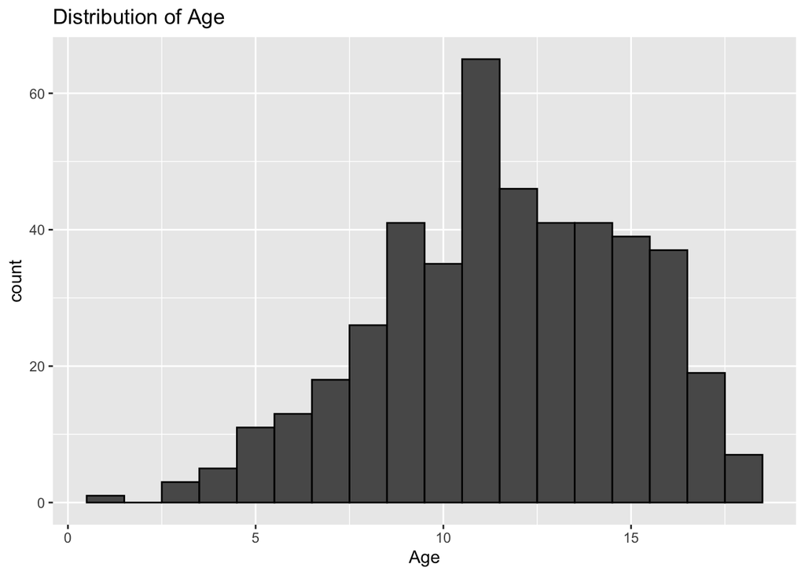

```r
library(ggplot2)
ggplot(clean_data, aes(x = Age)) + geom_histogram(binwidth = 1, color = "black") +
  ggtitle("Distribution of Age")
```

- The ages range from around 0 to 18.
- A slightly left skewed distribution

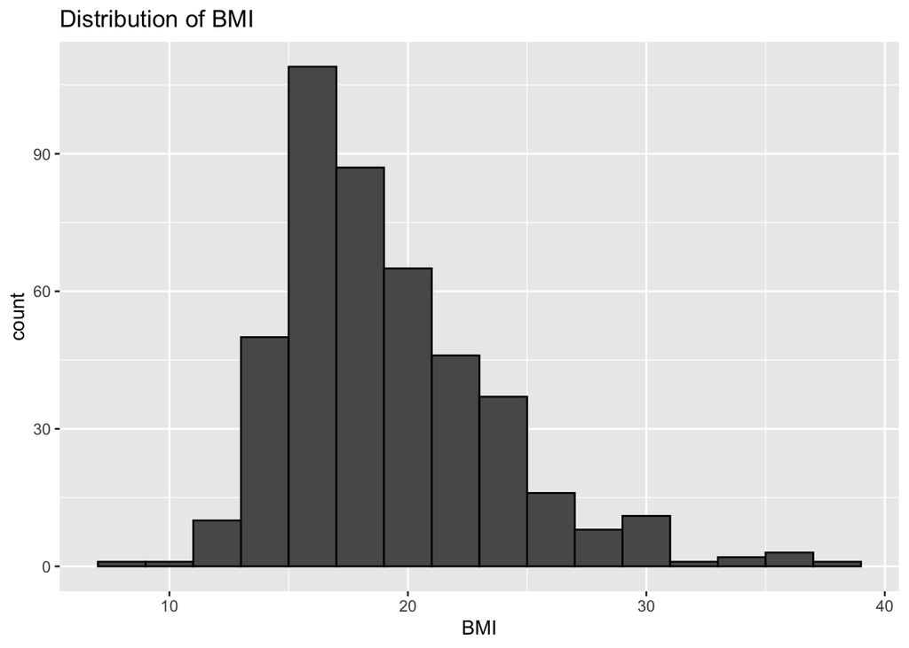

```r
ggplot(clean_data, aes(x = BMI)) + geom_histogram(binwidth = 2, color = "black") +
  ggtitle("Distribution of BMI")
```

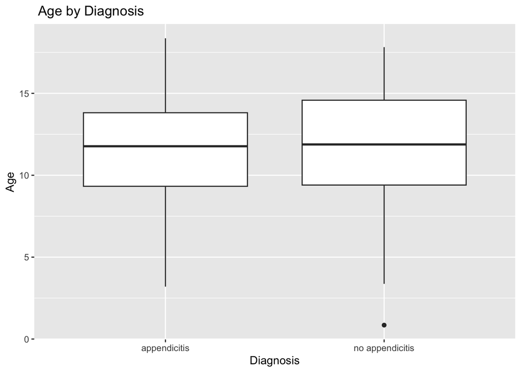

```r
ggplot(clean_data, aes(x = Diagnosis, y = Age)) + geom_boxplot() + ggtitle(" Age by Diagnosis")
```

- The median age and spread of ages are similar in both groups.

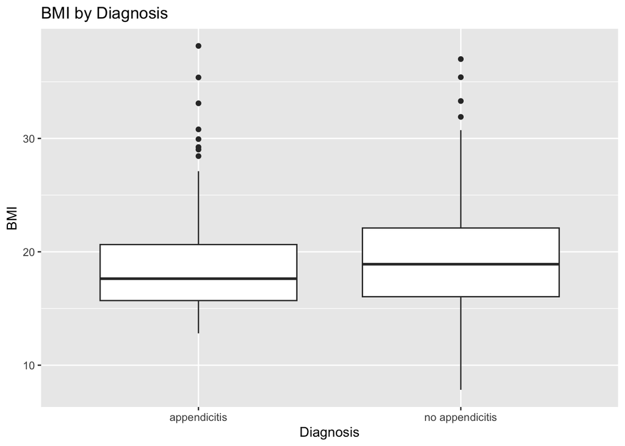

```r
ggplot(clean_data, aes(x = Diagnosis, y = BMI)) + geom_boxplot() + ggtitle("BMI by Diagnosis")
```

- The median BMI and spread of BMI are similar in both groups.

**Correlation Matrix**

```r
columns <- c("Weight" , "Alvarado_Score" , "Appendix_Diameter" ,"Body_Temperature" ,"WBC_Count" , "Thrombocyte_Count")

corr_vars <- clean_data[, columns]


cor_matrix <- cor(corr_vars, use = "complete.obs", method = "sp")

print(cor_matrix)
```

```
##                        Weight Alvarado_Score Appendix_Diameter Body_Temperature
## Weight             1.00000000     -0.2160264        0.06086416      -0.26016616
## Alvarado_Score    -0.21602636      1.0000000        0.25122389       0.42799322
## Appendix_Diameter  0.06086416      0.2512239        1.00000000       0.09783913
## Body_Temperature  -0.26016616      0.4279932        0.09783913       1.00000000
## WBC_Count         -0.21841710      0.6940544        0.26928572       0.27732247
## Thrombocyte_Count -0.22149115      0.1045716        0.05265165       0.02614180
##                    WBC_Count Thrombocyte_Count
## Weight            -0.2184171       -0.22149115
## Alvarado_Score     0.6940544        0.10457165
## Appendix_Diameter  0.2692857        0.05265165
## Body_Temperature   0.2773225        0.02614180
## WBC_Count          1.0000000        0.30825037
## Thrombocyte_Count  0.3082504        1.00000000
```

```r
help("methods")
```

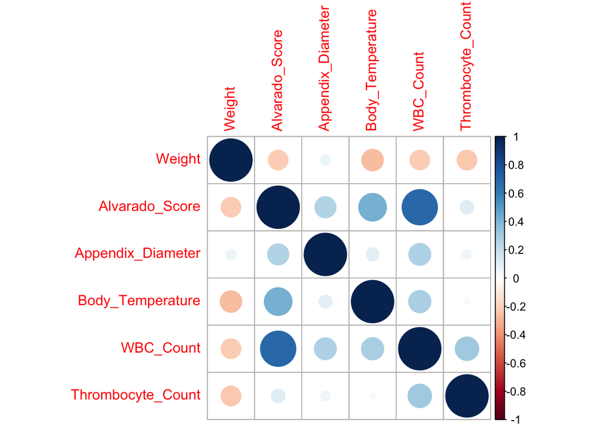

```r
library(corrplot)
corrplot(cor_matrix, method = "circle")
```

- Most variables have weak or very weak correlations.
- The Alvarado Score shows a moderate correlation with both WBC count (white blood cell count) and body temperature.

**Chi-Square Test**

Management

```r
chisq_test_results <- chisq.test(table(clean_data$Diagnosis, clean_data$Management))
print(chisq_test_results)
```

```
##
##  Pearson's Chi-squared test
##
## data:  table(clean_data$Diagnosis, clean_data$Management)
## X-squared = 98.437, df = 2, p-value < 2.2e-16
```

- The p-value (< 2.2e-16) is lower than the alpha value (0.05), indicating a significant association between the variables Diagnosis and Management.

Coughing

```r
chisq_test_results <- chisq.test(table(clean_data$Diagnosis, clean_data$Coughing_Pain))
print(chisq_test_results)
```

```
##
##  Pearson's Chi-squared test with Yates' continuity correction
##
## data:  table(clean_data$Diagnosis, clean_data$Coughing_Pain)
## X-squared = 6.7865, df = 1, p-value = 0.009185
```

- The p-value (0.009185) is lower than the alpha value (0.05), indicating a significant association between the variables Diagnosis and Coughing Pain.

Ultrasound on Appendix

```r
chisq_test_results <- chisq.test(table(clean_data$Diagnosis, clean_data$Appendix_on_US))
print(chisq_test_results)
```

```
##
##  Pearson's Chi-squared test with Yates' continuity correction
##
## data:  table(clean_data$Diagnosis, clean_data$Appendix_on_US)
## X-squared = 128.66, df = 1, p-value < 2.2e-16
```

- The p-value (<2.2e-16) is lower than the alpha value (0.05), indicating a significant association between the variables Diagnosis and Ultrasound on Appendix.

Nausea

```r
chisq_test_results <- chisq.test(table(clean_data$Diagnosis, clean_data$Nausea))
print(chisq_test_results)
```

```
##
##  Pearson's Chi-squared test with Yates' continuity correction
##
## data:  table(clean_data$Diagnosis, clean_data$Nausea)
## X-squared = 11.394, df = 1, p-value = 0.0007367
```

- The p-value (0.0007367) is lower than the alpha value (0.05), indicating a significant association between the variables Diagnosis and Nausea.

Neutrophilia

```r
chisq_test_results <- chisq.test(table(clean_data$Diagnosis, clean_data$Neutrophilia))
print(chisq_test_results)
```

```
##
##  Pearson's Chi-squared test with Yates' continuity correction
##
## data:  table(clean_data$Diagnosis, clean_data$Neutrophilia)
## X-squared = 16.26, df = 1, p-value = 5.521e-05
```

- The p-value (5.521e-05) is lower than the alpha value (0.05), indicating a significant association between the variables Diagnosis and Neutrophilia.

KNN Model

```r
# Load necessary libraries
library(dplyr)
library(caret)
library(class)

# Normalize numeric columns
numeric_columns <- clean_data %>%
  select(Weight, Alvarado_Score, Appendix_Diameter, Body_Temperature, WBC_Count, Thrombocyte_Count, Neutrophilia)

preProcess_values <- preProcess(numeric_columns, method = c("center", "scale"))
clean_data_normalized <- predict(preProcess_values, clean_data)

# Combine normalized numeric columns with categorical columns
clean_data_normalized <- cbind(
  clean_data_normalized[, c("Weight", "Alvarado_Score", "Appendix_Diameter", "Body_Temperature", "WBC_Count", "Thrombocyte_Count", "Neutrophilia")],
  clean_data[, c("Management", "Appendix_on_US", "Coughing_Pain", "Nausea", "Diagnosis")]
)

# Select relevant columns
selected_columns <- c("Weight", "Management", "Alvarado_Score", "Appendix_on_US", "Appendix_Diameter", "Coughing_Pain",
                      "Nausea", "Body_Temperature", "WBC_Count", "Thrombocyte_Count", "Neutrophilia", "Diagnosis")
clean_data_normalized <- clean_data_normalized[, selected_columns]

# Remove rows with missing values
clean_data_normalized <- na.omit(clean_data_normalized)

# Split data into training and testing sets
set.seed(2024)
train_index <- createDataPartition(clean_data_normalized$Diagnosis, p = 0.8, list = FALSE)
auto.training <- clean_data_normalized[train_index, ]
auto.testing <- clean_data_normalized[-train_index, ]

X.train <- auto.training[, -ncol(auto.training)]
Y.train <- auto.training$Diagnosis
X.test <- auto.testing[, -ncol(auto.testing)]
Y.test <- auto.testing$Diagnosis


X.train <- model.matrix(~ . -1, data = X.train)
X.test <- model.matrix(~ . -1, data = X.test)

# Fit KNN model
set.seed(2024)
append.knn <- knn(train = X.train, test = X.test, cl = Y.train, k = 6)

# Confusion matrix and accuracy
conf_matrix <- table(Y.test, append.knn)
print(conf_matrix)
```

```
##                  append.knn
## Y.test            appendicitis no appendicitis
##   appendicitis              27              13
##   no appendicitis            2              47
```

```r
test_accuracy <- mean(Y.test == append.knn)
print(paste("Test accuracy with k=6:", test_accuracy))
```

```
## [1] "Test accuracy with k=6: 0.831460674157303"
```

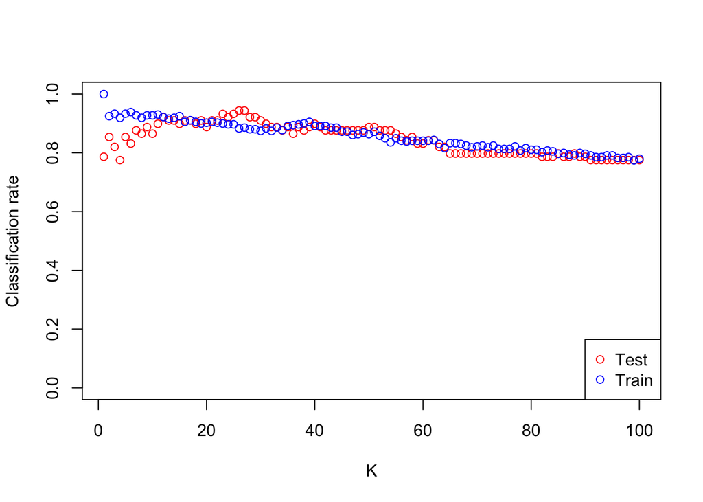

```r
# optimal value of K
Kmax <- 100
class.rate.test <- rep(0, Kmax)
class.rate.train <- rep(0, Kmax)

for (i in 1:Kmax) {
  knn.test <- knn(train = X.train, test = X.test, cl = Y.train, k = i)
  knn.train <- knn(train = X.train, test = X.train, cl = Y.train, k = i)
  class.rate.test[i] <- mean(Y.test == knn.test)
  class.rate.train[i] <- mean(Y.train == knn.train)
}

# Plot classification rates
plot(c(1:Kmax), class.rate.test, type = "p", col = "red", xlab = "K", ylab = "Classification rate", ylim = c(0, 1))
points(c(1:Kmax), class.rate.train, col = "blue")
legend("bottomright", legend = c("Test", "Train"), col = c("red", "blue"), pch = 1)
```

```r
# refit the model with optimal k
k.opt <- which.max(class.rate.test)
print(c(k.opt, class.rate.test[which.max(class.rate.test)]))
```

```
## [1] 26.0000000  0.9438202
```

```r
# Fit KNN model with the optimal k
append.knnOpt <- knn(train = X.train, test = X.test, cl = Y.train, k = k.opt)

# Confusion matrix and accuracy  - testing
conf_matrix_opt <- table(Y.test, append.knnOpt)
print(conf_matrix_opt)
```

```
##                  append.knnOpt
## Y.test            appendicitis no appendicitis
##   appendicitis              33               7
##   no appendicitis            2              47
```

```r
test_accuracy_opt <- mean(Y.test == append.knnOpt)
print(paste("Test accuracy with optimal k:", test_accuracy_opt))
```

```
## [1] "Test accuracy with optimal k: 0.898876404494382"
```

```r
# Confusion matrix and accuracy - training
train_knn_opt <- knn(train = X.train, test = X.train, cl = Y.train, k = k.opt)
conf_matrix_train_opt <- table(Y.train, train_knn_opt)
print(conf_matrix_train_opt)
```

```
##                  train_knn_opt
## Y.train           appendicitis no appendicitis
##   appendicitis             133              30
##   no appendicitis           10             186
```

```r
train_accuracy_opt <- mean(Y.train == train_knn_opt)
print(paste("Train accuracy with optimal k:", train_accuracy_opt))
```

```
## [1] "Train accuracy with optimal k: 0.88857938718663"
```

KNN Model with Cross Validation

```r
library(dplyr)
library(caret)
library(class)

# Normalize numeric columns
numeric_columns <- clean_data %>%
  select(Weight, Alvarado_Score, Appendix_Diameter, Body_Temperature, WBC_Count, Thrombocyte_Count, Neutrophilia)

preProcess_values <- preProcess(numeric_columns, method = c("center", "scale"))
clean_data_normalized <- predict(preProcess_values, clean_data)

# Combine normalized numeric columns with categorical columns
clean_data_normalized <- cbind(
  clean_data_normalized[, c("Weight", "Alvarado_Score", "Appendix_Diameter", "Body_Temperature", "WBC_Count", "Thrombocyte_Count", "Neutrophilia")],
  clean_data[, c("Management", "Appendix_on_US", "Coughing_Pain", "Nausea", "Diagnosis")]
)

# Select relevant columns
selected_columns <- c("Weight", "Management", "Alvarado_Score", "Appendix_on_US", "Appendix_Diameter", "Coughing_Pain",
                      "Nausea", "Body_Temperature", "WBC_Count", "Thrombocyte_Count", "Neutrophilia", "Diagnosis")
clean_data_normalized <- clean_data_normalized[, selected_columns]

# Remove rows with missing values
clean_data_normalized <- na.omit(clean_data_normalized)

# Split data into training and testing sets
set.seed(2024)
train_index <- createDataPartition(clean_data_normalized$Diagnosis, p = 0.8, list = FALSE)
auto.training <- clean_data_normalized[train_index, ]
auto.testing <- clean_data_normalized[-train_index, ]

X.train <- auto.training[, -ncol(auto.training)]
Y.train <- auto.training$Diagnosis
X.test <- auto.testing[, -ncol(auto.testing)]
Y.test <- auto.testing$Diagnosis

# Matrix form
X.train <- model.matrix(~ . -1, data = X.train)
X.test <- model.matrix(~ . -1, data = X.test)

# Cross-validation to find the optimal k
set.seed(2024)
train_control <- trainControl(method = "cv", number = 10)
knn_fit <- train(x = X.train, y = Y.train, method = "knn", trControl = train_control, tuneLength = 10)

#best tuning parameter k
print(knn_fit$bestTune)
```

```
##   k
## 3 9
```

```r
# Fit KNN model
optimal_k <- knn_fit$bestTune$k
append.knnOpt <- knn(train = X.train, test = X.test, cl = Y.train, k = optimal_k)

# Confusion matrix and accuracy
conf_matrix_opt <- table(Y.test, append.knnOpt)
print(conf_matrix_opt)
```

```
##                  append.knnOpt
## Y.test            appendicitis no appendicitis
##   appendicitis              31               9
##   no appendicitis            1              48
```

```r
test_accuracy_opt <- mean(Y.test == append.knnOpt)
print(paste("Test accuracy with optimal k:", test_accuracy_opt))
```

```
## [1] "Test accuracy with optimal k: 0.887640449438202"
```

```r
# Confusion matrix and accuracy
train_knn_opt <- knn(train = X.train, test = X.train, cl = Y.train, k = optimal_k)
conf_matrix_train_opt <- table(Y.train, train_knn_opt)
print(conf_matrix_train_opt)
```

```
##                  train_knn_opt
## Y.train           appendicitis no appendicitis
##   appendicitis             145              18
##   no appendicitis            8             188
```

```r
train_accuracy_opt <- mean(Y.train == train_knn_opt)
print(paste("Train accuracy with optimal k:", train_accuracy_opt))
```

```
## [1] "Train accuracy with optimal k: 0.927576601671309"
```

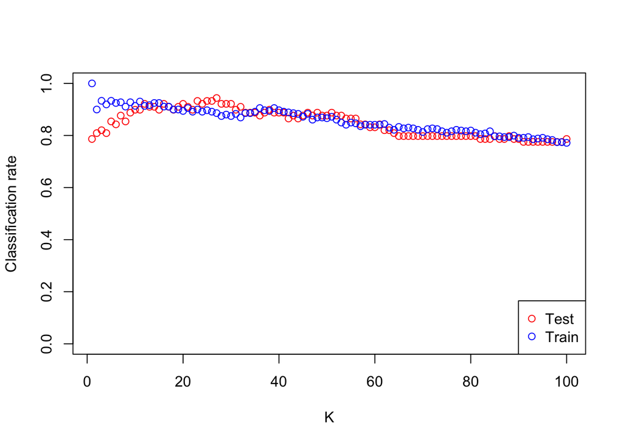

```r
#classification rate for different values of K
Kmax <- 100
class.rate.test <- rep(0, Kmax)
class.rate.train <- rep(0, Kmax)

for (i in 1:Kmax) {
  knn.test <- knn(train = X.train, test = X.test, cl = Y.train, k = i)
  knn.train <- knn(train = X.train, test = X.train, cl = Y.train, k = i)
  class.rate.test[i] <- mean(Y.test == knn.test)
  class.rate.train[i] <- mean(Y.train == knn.train)
}

# Plot classification rates
plot(c(1:Kmax), class.rate.test, type = "p", col = "red", xlab = "K", ylab = "Classification rate", ylim = c(0, 1))
points(c(1:Kmax), class.rate.train, col = "blue")
legend("bottomright", legend = c("Test", "Train"), col = c("red", "blue"), pch = 1)
```

```r
# Print the optimal K
print(paste("Optimal K from cross-validation:", optimal_k))
```

```
## [1] "Optimal K from cross-validation: 9"
```

```r
total_conf_matrix <- table(c(Y.train, Y.test), c(train_knn_opt, append.knnOpt))
overall_accuracy <- mean(c(Y.train, Y.test) == c(train_knn_opt, append.knnOpt))
print(total_conf_matrix)
```

```
##
##                   appendicitis no appendicitis
##   appendicitis             176              27
##   no appendicitis            9             236
```

```r
print(paste("Overall accuracy with optimal k:", overall_accuracy))
```

```
## [1] "Overall accuracy with optimal k: 0.919642857142857"
```

Holdout Data - KNN

```r
library(dplyr)
library(caret)
library(class)

# Normalize numeric columns
numeric_columns <- clean_data %>%
  select(Weight, Alvarado_Score, Appendix_Diameter, Body_Temperature, WBC_Count, Thrombocyte_Count, Neutrophilia)

preProcess_values <- preProcess(numeric_columns, method = c("center", "scale"))
clean_data_normalized <- predict(preProcess_values, clean_data)

# Combine normalized numeric columns with categorical columns
clean_data_normalized <- cbind(
  clean_data_normalized[, c("Weight", "Alvarado_Score", "Appendix_Diameter", "Body_Temperature", "WBC_Count", "Thrombocyte_Count", "Neutrophilia")],
  clean_data[, c("Management", "Appendix_on_US", "Coughing_Pain", "Nausea", "Diagnosis")]
)

# Select relevant columns
selected_columns <- c("Weight", "Management", "Alvarado_Score", "Appendix_on_US", "Appendix_Diameter", "Coughing_Pain",
                      "Nausea", "Body_Temperature", "WBC_Count", "Thrombocyte_Count", "Neutrophilia", "Diagnosis")
clean_data_normalized <- clean_data_normalized[, selected_columns]

# Remove rows with missing values
clean_data_normalized <- na.omit(clean_data_normalized)

# Split data
set.seed(2024)
holdout_index <- createDataPartition(clean_data_normalized$Diagnosis, p = 0.2, list = FALSE)
holdout_data <- clean_data_normalized[holdout_index, ]
training_validation_data <- clean_data_normalized[-holdout_index, ]

# Split data
train_index <- createDataPartition(training_validation_data$Diagnosis, p = 0.8, list = FALSE)
auto.training <- training_validation_data[train_index, ]
auto.validation <- training_validation_data[-train_index, ]

X.train <- auto.training[, -ncol(auto.training)]
Y.train <- auto.training$Diagnosis
X.validation <- auto.validation[, -ncol(auto.validation)]
Y.validation <- auto.validation$Diagnosis
X.holdout <- holdout_data[, -ncol(holdout_data)]
Y.holdout <- holdout_data$Diagnosis

#Matrix form
X.train <- model.matrix(~ . -1, data = X.train)
X.validation <- model.matrix(~ . -1, data = X.validation)
X.holdout <- model.matrix(~ . -1, data = X.holdout)

# Fit KNN model
set.seed(2024)
optimal_k <- 6  # Set the k value as per your previous model without cross-validation
append.knn <- knn(train = X.train, test = X.validation, cl = Y.train, k = optimal_k)

# Confusion matrix
conf_matrix_validation <- table(Y.validation, append.knn)
print(conf_matrix_validation)
```

```
##                  append.knn
## Y.validation      appendicitis no appendicitis
##   appendicitis              26               6
##   no appendicitis            5              34
```

```r
validation_accuracy <- mean(Y.validation == append.knn)
print(paste("Validation accuracy with k =", optimal_k, ":", validation_accuracy))
```

```
## [1] "Validation accuracy with k = 6 : 0.845070422535211"
```

```r
# Confusion matrix
train_knn <- knn(train = X.train, test = X.train, cl = Y.train, k = optimal_k)
conf_matrix_train <- table(Y.train, train_knn)
print(conf_matrix_train)
```

```
##                  train_knn
## Y.train           appendicitis no appendicitis
##   appendicitis             112              18
##   no appendicitis           11             146
```

```r
train_accuracy <- mean(Y.train == train_knn)
print(paste("Train accuracy with k =", optimal_k, ":", train_accuracy))
```

```
## [1] "Train accuracy with k = 6 : 0.898954703832753"
```

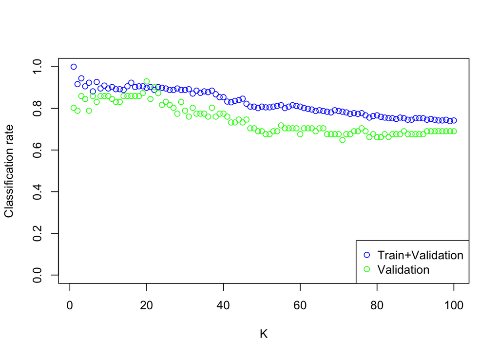

```r
# Classification rate
Kmax <- 100
class.rate.train_validation <- rep(0, Kmax)
class.rate.validation <- rep(0, Kmax)

for (i in 1:Kmax) {
  knn.train_validation <- knn(train = X.train, test = X.train, cl = Y.train, k = i)
  knn.validation <- knn(train = X.train, test = X.validation, cl = Y.train, k = i)
  class.rate.train_validation[i] <- mean(Y.train == knn.train_validation)
  class.rate.validation[i] <- mean(Y.validation == knn.validation)
}

#Plot for Classification rates
plot(c(1:Kmax), class.rate.train_validation, type = "p", col = "blue", xlab = "K", ylab = "Classification rate", ylim = c(0, 1))
points(c(1:Kmax), class.rate.validation, col = "green")
legend("bottomright", legend = c("Train+Validation", "Validation"), col = c("blue", "green"), pch = 1)
```

```r
# Evaluate  model on holdout data
append.knnOpt_holdout <- knn(train = X.train, test = X.holdout, cl = Y.train, k = optimal_k)

# Confusion matrix +  accuracy for holdout data (optimal k)
conf_matrix_holdout <- table(Y.holdout, append.knnOpt_holdout)
print(conf_matrix_holdout)
```

```
##                  append.knnOpt_holdout
## Y.holdout         appendicitis no appendicitis
##   appendicitis              33               8
##   no appendicitis            1              48
```

```r
holdout_accuracy_opt <- mean(Y.holdout == append.knnOpt_holdout)
print(paste("Holdout accuracy with optimal k:", holdout_accuracy_opt))
```

```
## [1] "Holdout accuracy with optimal k: 0.9"
```

```r
#Accuracy with holdout data
overall_accuracy <- mean(Y.holdout == append.knnOpt_holdout)
print(paste("Overall accuracy with holdout data:", overall_accuracy))
```

```
## [1] "Overall accuracy with holdout data: 0.9"
```

**Logistic Regression**

```r
AIC_final_model<- glm(Diagnosis ~ Weight + Management + Alvarado_Score +
    Appendix_on_US + Appendix_Diameter + Coughing_Pain + Nausea +
    Body_Temperature + WBC_Count + Thrombocyte_Count + Neutrophilia,
    family = "binomial", data = clean_data)
Probability <- predict(AIC_final_model, auto.testing, type ="response")
Predicted.Diagnosis <- ifelse(Probability >= .5, "appendicitis", "no appendicitis")
table(auto.testing$Diagnosis, Predicted.Diagnosis)
```

```
##                  Predicted.Diagnosis
##                   appendicitis no appendicitis
##   appendicitis               0              40
##   no appendicitis           30              19
```

```r
mean(auto.testing$Diagnosis == Predicted.Diagnosis)
```

```
## [1] 0.2134831
```

Holdout Data - Logistic Regression

```r
library(dplyr)
library(caret)

# Split data
set.seed(2024)
holdout_index <- createDataPartition(clean_data$Diagnosis, p = 0.2, list = FALSE)
holdout_data <- clean_data[holdout_index, ]
training_validation_data <- clean_data[-holdout_index, ]

# Fit logistic regression model
AIC_final_model <- glm(Diagnosis ~ Weight + Management + Alvarado_Score +
                         Appendix_on_US + Appendix_Diameter + Coughing_Pain + Nausea +
                         Body_Temperature + WBC_Count + Thrombocyte_Count + Neutrophilia,
                       family = "binomial", data = training_validation_data)
# Evaluate model on holdout data
Probability_holdout <- predict(AIC_final_model, holdout_data, type ="response")
Predicted.Diagnosis_holdout <- ifelse(Probability_holdout >= .5, "appendicitis", "no appendicitis")

# Confusion matrix
conf_matrix_holdout <- table(holdout_data$Diagnosis, Predicted.Diagnosis_holdout)
print(conf_matrix_holdout)
```

```
##                  Predicted.Diagnosis_holdout
##                   appendicitis no appendicitis
##   appendicitis               5              36
##   no appendicitis           47               2
```

```r
holdout_accuracy <- mean(holdout_data$Diagnosis == Predicted.Diagnosis_holdout)
print(paste("Holdout accuracy:", holdout_accuracy))
```

```
## [1] "Holdout accuracy: 0.0777777777777778"
```

```r
# Holdout Data Accuracy
true_positives <- conf_matrix_holdout["appendicitis", "appendicitis"]
true_negatives <- conf_matrix_holdout["no appendicitis", "no appendicitis"]
total_correct <- true_positives + true_negatives
total_holdout <- sum(conf_matrix_holdout)
overall_accuracy_holdout <- total_correct / total_holdout
print(paste("Overall accuracy with holdout data:", overall_accuracy_holdout))
```

```
## [1] "Overall accuracy with holdout data: 0.0777777777777778"
```

```r
# Confusion matrix
Probability_training_validation <- predict(AIC_final_model, training_validation_data, type ="response")
Predicted.Diagnosis_training_validation <- ifelse(Probability_training_validation >= .5, "appendicitis", "no appendicitis")

conf_matrix_training_validation <- table(training_validation_data$Diagnosis, Predicted.Diagnosis_training_validation)
print(conf_matrix_training_validation)
```

```
##                  Predicted.Diagnosis_training_validation
##                   appendicitis no appendicitis
##   appendicitis              10             152
##   no appendicitis          183              13
```

```r
training_validation_accuracy <- mean(training_validation_data$Diagnosis == Predicted.Diagnosis_training_validation)
print(paste("Training+validation accuracy:", training_validation_accuracy))
```

```
## [1] "Training+validation accuracy: 0.0642458100558659"
```

```r
# Accuracy
true_positives_train <- conf_matrix_training_validation["appendicitis", "appendicitis"]
true_negatives_train <- conf_matrix_training_validation["no appendicitis", "no appendicitis"]
total_correct_train <- true_positives_train + true_negatives_train
total_train <- sum(conf_matrix_training_validation)
overall_accuracy_training_validation <- total_correct_train / total_train
print(paste("Overall accuracy with training+validation data:", overall_accuracy_training_validation))
```

```
## [1] "Overall accuracy with training+validation data: 0.0642458100558659"
```

- Using AIC model.
- Classification rate: 21.35%
- The classification rate of the logistic regression model is much lower than that of the KNN model.
- The classification rate with holdout data: 7%
- The logistic regression model performs significantly worse on holdout data, with a 7% accuracy compared to 21% for the initial model.

**LDA**

```r
library(MASS)
lda.fit<- lda(Diagnosis ~ Weight + Management + Alvarado_Score +
    Appendix_on_US + Appendix_Diameter + Coughing_Pain + Nausea +
    Body_Temperature + WBC_Count + Thrombocyte_Count + Neutrophilia,data = clean_data)
Predicted.Diagonsis_lda <- predict(lda.fit, clean_data)$class
table(clean_data$Diagnosis, Predicted.Diagonsis_lda)
```

```
##                  Predicted.Diagonsis_lda
##                   appendicitis no appendicitis
##   appendicitis             172              31
##   no appendicitis           10             235
```

```r
mean(clean_data$Diagnosis==Predicted.Diagonsis_lda)
```

```
## [1] 0.9084821
```

LDA with Holdout Data

```r
library(MASS)
library(caret)

# Split data
set.seed(2024)
holdout_index <- createDataPartition(clean_data$Diagnosis, p = 0.2, list = FALSE)
holdout_data <- clean_data[holdout_index, ]
training_validation_data <- clean_data[-holdout_index, ]

# Fit LDA model
lda.fit <- lda(Diagnosis ~ Weight + Management + Alvarado_Score +
                 Appendix_on_US + Appendix_Diameter + Coughing_Pain + Nausea +
                 Body_Temperature + WBC_Count + Thrombocyte_Count + Neutrophilia,
               data = training_validation_data)

# Evaluate LDA model on Holdout
Predicted.Diagonsis_lda_holdout <- predict(lda.fit, holdout_data)$class
conf_matrix_lda_holdout <- table(holdout_data$Diagnosis, Predicted.Diagonsis_lda_holdout)
print(conf_matrix_lda_holdout)
```

```
##                  Predicted.Diagonsis_lda_holdout
##                   appendicitis no appendicitis
##   appendicitis              33               8
##   no appendicitis            0              49
```

```r
holdout_accuracy_lda <- mean(holdout_data$Diagnosis == Predicted.Diagonsis_lda_holdout)
print(paste("LDA Holdout accuracy:", holdout_accuracy_lda))
```

```
## [1] "LDA Holdout accuracy: 0.911111111111111"
```

```r
# Accuracy

true_positives_lda <- conf_matrix_lda_holdout["appendicitis", "appendicitis"]
true_negatives_lda <- conf_matrix_lda_holdout["no appendicitis", "no appendicitis"]
total_correct_lda <- true_positives_lda + true_negatives_lda
total_holdout_lda <- sum(conf_matrix_lda_holdout)
overall_accuracy_holdout_lda <- total_correct_lda / total_holdout_lda
print(paste("Overall accuracy with holdout data for LDA:", overall_accuracy_holdout_lda))
```

```
## [1] "Overall accuracy with holdout data for LDA: 0.911111111111111"
```

```r
# Evaluate LDA model
Predicted.Diagonsis_lda_train <- predict(lda.fit, training_validation_data)$class
conf_matrix_lda_train <- table(training_validation_data$Diagnosis, Predicted.Diagonsis_lda_train)
print(conf_matrix_lda_train)
```

```
##                  Predicted.Diagonsis_lda_train
##                   appendicitis no appendicitis
##   appendicitis             130              32
##   no appendicitis           10             186
```

```r
training_accuracy_lda <- mean(training_validation_data$Diagnosis == Predicted.Diagonsis_lda_train)
print(paste("LDA Training+validation accuracy:", training_accuracy_lda))
```

```
## [1] "LDA Training+validation accuracy: 0.88268156424581"
```

**QDA**

```r
library(MASS)
logit_model <- glm(Diagnosis ~ Weight + Management + Alvarado_Score +
                     Appendix_on_US + Appendix_Diameter + Coughing_Pain + Nausea +
                     Body_Temperature + WBC_Count + Thrombocyte_Count + Neutrophilia,
                   data = clean_data, family = binomial)
qda_fit <- qda(Diagnosis ~ Weight + Alvarado_Score +
                 Coughing_Pain + Nausea + Body_Temperature,
               data = clean_data)


Predicted.Diagonsis_qda <- predict(qda_fit, clean_data)$class

table(clean_data$Diagnosis, Predicted.Diagonsis_qda)
```

```
##                  Predicted.Diagonsis_qda
##                   appendicitis no appendicitis
##   appendicitis             128              75
##   no appendicitis           79             166
```

```r
mean(clean_data$Diagnosis==Predicted.Diagonsis_qda)
```

```
## [1] 0.65625
```

QDA with Holdout Data

```r
library(MASS)
library(caret)

# Split data
set.seed(2024)
holdout_index <- createDataPartition(clean_data$Diagnosis, p = 0.2, list = FALSE)
holdout_data <- clean_data[holdout_index, ]
training_validation_data <- clean_data[-holdout_index, ]

# Fit QDA model
qda_fit <- qda(Diagnosis ~ Weight + Alvarado_Score +
                 Coughing_Pain + Nausea + Body_Temperature,
               data = training_validation_data)

# Evaluate QDA model on holdout data
Predicted.Diagonsis_qda_holdout <- predict(qda_fit, holdout_data)$class
conf_matrix_qda_holdout <- table(holdout_data$Diagnosis, Predicted.Diagonsis_qda_holdout)
print(conf_matrix_qda_holdout)
```

```
##                  Predicted.Diagonsis_qda_holdout
##                   appendicitis no appendicitis
##   appendicitis              25              16
##   no appendicitis           13              36
```

```r
holdout_accuracy_qda <- mean(holdout_data$Diagnosis == Predicted.Diagonsis_qda_holdout)
print(paste("QDA Holdout accuracy:", holdout_accuracy_qda))
```

```
## [1] "QDA Holdout accuracy: 0.677777777777778"
```

```r
#accuracy
true_positives_qda <- conf_matrix_qda_holdout["appendicitis", "appendicitis"]
true_negatives_qda <- conf_matrix_qda_holdout["no appendicitis", "no appendicitis"]
total_correct_qda <- true_positives_qda + true_negatives_qda
total_holdout_qda <- sum(conf_matrix_qda_holdout)
overall_accuracy_holdout_qda <- total_correct_qda / total_holdout_qda
print(paste("Overall accuracy with holdout data (QDA):", overall_accuracy_holdout_qda))
```

```
## [1] "Overall accuracy with holdout data (QDA): 0.677777777777778"
```

```r
# Evaluate QDA model
Predicted.Diagonsis_qda_train <- predict(qda_fit, training_validation_data)$class
conf_matrix_qda_train <- table(training_validation_data$Diagnosis, Predicted.Diagonsis_qda_train)
print(conf_matrix_qda_train)
```

```
##                  Predicted.Diagonsis_qda_train
##                   appendicitis no appendicitis
##   appendicitis              92              70
##   no appendicitis           58             138
```

```r
training_accuracy_qda <- mean(training_validation_data$Diagnosis == Predicted.Diagonsis_qda_train)
print(paste("QDA Training+validation accuracy:", training_accuracy_qda))
```

```
## [1] "QDA Training+validation accuracy: 0.642458100558659"
```

Summary:

- Since the KNN model has the highest correct prediction rate, we recommend using KNN for this dataset.